# Vectors: practice I

Eddie

## Building vectors

1. Build the following vectors using the colon operator: `:`.

$$\{-1, 0, 1, 2\} \\
\{2, 1, 0, -1\}$$

```r
-1:2
```

```
## [1] -1  0  1  2
```

```r
2:-1
```

```
## [1]  2  1  0 -1
```

1. Build the following vectors using `seq()`.

$$\{-1, 0, 1, 2\} \\
\{2, 4, 6, 8, 10, 12\} \\
\{2, 3.5, 5, 6.5\}$$

```r
seq(-1, 2, 1)
```

```
## [1] -1  0  1  2
```

```r
seq(2, 12, 2)
```

```
## [1]  2  4  6  8 10 12
```

```r
seq(2, 7, 1.5)
```

```
## [1] 2.0 3.5 5.0 6.5
```

1. Build the following vectors using `rep()`.

$$\{1, 2, 3, 1, 2, 3, 1, 2, 3\} \\
\{1, 1, 2, 2, 3, 3\} \\
\{1, 1, 2, 3, 3\} \\
\{1, 2, 3, 1, 2, 3, 1\} \\
\{1, 1, 2, 2, 3, 3, 1, 1, 2, 2, 3, 3, 1, 1, 2, 2, 3, 3\}$$

```r
rep(c(1, 2, 3), 3)
```

```
## [1] 1 2 3 1 2 3 1 2 3
```

```r
c(rep(1, 2), rep(2, 2), rep(3, 2))
```

```
## [1] 1 1 2 2 3 3
```

```r
c(rep(1, 2), 2, rep(3, 2))
```

```
## [1] 1 1 2 3 3
```

```r
c(rep(c(1, 2, 3), 2), 1)
```

```
## [1] 1 2 3 1 2 3 1
```

```r
rep(c(rep(1, 2), rep(2, 2), rep(3, 2)), 3)
```

```
##  [1] 1 1 2 2 3 3 1 1 2 2 3 3 1 1 2 2 3 3
```

## Manipulating vectors

Please paste the following commands into your Rstudio session, in order to set up the following exercises.

```r
require('ggplot2')
load(url('http://www.stolaf.edu/people/olaf/cs125/hw8.RData'))
```

If at some point you want to restore the data, it is fine to paste these commands in again whenever you need them.

Let’s see whether the drawing function is working correctly. Try typing in the following command, and see what it does:

[figure not shown]

```r
draw(p0x, p0y)
```

If all goes well, a simple sketch of Calvin should appear. If you print `p0x`, you will see that it is a vector of numbers, and p0y is another vector of numbers, both of the same length. `p0x` and `p0y` contain the x and y coordinates, respectively, of the points along the line segments that make up the simple Calvin sketch. As an experiment, try the following:

[figure not shown]

```r
draw(p0x, p0y+25)
```

Hopefully, the result is that Calvin appeared to move up a distance of 25 units. Before proceeding with the exercises, please think through what is happening with these commands, since it will be easier to answer the following questions if you clearly understand how the two vectors are related to the plot.

1. If you now draw the next set of vectors:

[figure not shown]

```r
draw(p1x, p1y)
```

you will see Calvin’s buddy Hobbes, except that there is a problem with the data: the points that are part of Hobbes on the right side have been mistakenly moved up by 25 units. Please fix this problem, so that drawing `p1x` with `p1y` results in a more plausible rendering of Hobbes.

[figure not shown]

```r
new.p1y <- p1y
new.p1y[p1x > 50] <- new.p1y[p1x > 50]-25
draw(p1x, new.p1y)
```

2. Let’s take a look at the second example:

[figure not shown]

```r
draw(p2x, p2y)
```

here, we almost have four duplicates of Calvin in several places, but the upper right drawing has been shifted to the left. Please move that part of the drawing to the right, so that the four Calvins are symmetrically placed (the same distance apart both horizontally and vertically).

[figure not shown]

```r
new.p2x <- p2x
new.p2x[p2x > 45 & p2y > 50] <- new.p2x[p2x > 45 & p2y > 50]+15
draw(new.p2x, p2y)
```

Here is way to find the desired offset programatically.

[figure not shown]

```r
# Find median of upper right Calvin
shifted.center <- mean(p2x[p2x > 45 & p2x < 100 & p2y > 50])
# Find median of lower right Calvie
target.center <- mean(p2x[p2x > 45 & p2x < 100 & p2y < 50])
# Calculate amount to shift
amount.to.shift <- target.center - shifted.center

new.p2x <- p2x
new.p2x[p2x > 45 & p2y > 50] <- new.p2x[p2x > 45 & p2y > 50] + amount.to.shift
draw(new.p2x, p2y)
```

3. Let’s take a look at the third example:

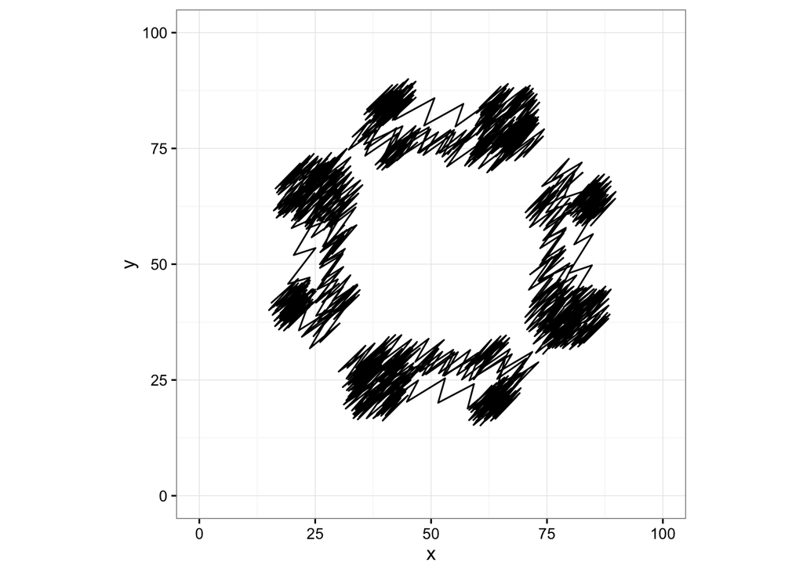

```r
draw(p3x, p3y)
```

here, we almost have four duplicates of Hobbes in several places, but every other point has been moved five units up and to the right, making it almost impossible to see Hobbes anywhere. Try to resolve the four duplicates of Hobbes.

[figure not shown]

```r
new.p3x <- p3x
new.p3y <- p3y

new.p3x[seq(1, length(new.p3y), 2)] <- new.p3x[seq(1, length(new.p3y), 2)] - 5
new.p3y[seq(1, length(new.p3y), 2)] <- new.p3y[seq(1, length(new.p3y), 2)] - 5

draw(new.p3x, new.p3y)
```

Adapted from material developed by Olaf Hall-Holt and Paul Roback for CS 125 at St. Olaf College.